# Analyzing political candidates with politicxsentwitteR!

Guadalupe Gonzalez

2023-05-03

From the [Network Observatory](https://twitter.com/O_de_R) together with [Democracia en Red](https://twitter.com/fundacionDER) and the [National Democratic Institute](https://twitter.com/NDI) we are excited to announce the relaunch of our [PoliticxsentwitteR website](https://oderedes.shinyapps.io/PoliticxsentwitteR/), now with updated data up to June 2022!

[figure not shown]

The app that I have the honor to develop analyzes tweets from **politicians in Argentina** and provides insights into their **engagement, the words and emojis** that they use, and also **who retweets who**. It also provides the opportunity to **free download the tweets** so they can be analyzed and give users a more comprehensive view of political discourse on Twitter.

We hope that this update will provide valuable insights into political discourse in Argentina, and we encourage you to give it a try. You can access the app by visiting [this link](https://oderedes.shinyapps.io/PoliticxsentwitteR/)

Another important announcement is that **[politicxsintwitteR R package](https://github.com/guadag12/politicxsentwitteR/) is also available** to make the data as much accessible as possible. In this [post](https://guadag12.github.io/politicxsentwitteR/articles/Instalacion-y-funciones.html) I showed you what opportunities the package bring! Also, you can check this [social network tutorial](https://www.youtube.com/watch?v=BSU82auREmw&ab_channel=RLadiesBuenosAires) that I present thanks to [R ladies Buenos Aires](https://twitter.com/RLadiesBA) using [politicxsintwitteR](https://github.com/guadag12/politicxsentwitteR/).

However, how if we try to do a little network analysis as a showed up of the possibilities of the package?

## Network Analysis with [politicxsintwitteR](https://github.com/guadag12/politicxsentwitteR/)

### 1. Import libraries:

```r
options(scipen=9999)

library(politicxsentwitteR)
library(tidyverse)
library(ggraph)
library(igraph)
library(gt)
library(stringr)
library(stringi)
library(gtExtras)
library(rmarkdown)
library(tidygraph)
```

### 2.Import data using “get_network_data()” function

```r
data <-  get_network_data("all", start_date = "2021-06-01",end_date = "2021-12-31")
data <- data.frame(lapply(data, as.character), stringsAsFactors=FALSE)
data$value <- as.numeric(as.character(data$value))
data <- data[!is.na(data$retweet_user_id), ]
data <- data[!is.na(data$user_id), ]
paged_table(head(data))
```

|  | created_at | user_id | retweet_user_id | value |
| --- | --- | --- | --- | --- |
| 1 | 2021-08-01 | 1006431284 | 1006431284 | 2 |
| 2 | 2021-08-01 | 1006431284 | 1006431284 | 2 |
| 3 | 2021-11-01 | 1006431284 | 1132308934948282368 | 1 |
| 4 | 2021-08-01 | 1006431284 | 1197039757 | 1 |
| 5 | 2021-08-01 | 1006431284 | 144307376 | 1 |
| 6 | 2021-10-01 | 1006431284 | 144929758 | 1 |

```r
data_colors <- read_csv("https://raw.githubusercontent.com/guadag12/configuration_db/main/data_colors.csv")
data_colors <- data.frame(lapply(data_colors, as.character), stringsAsFactors=FALSE)
paged_table(head(data_colors))
```

|  | user_id | screen_name | description | profile_image_url | Tipo_organismo | database | Color |
| --- | --- | --- | --- | --- | --- | --- | --- |
| 1 | 1034832158 | PatoVasquezOk | Abogada especialista en Magistratura, defensora de la Democracia, la Republica y el Estado de Derecho. Precandidata a Diputada Nacional por la Provincia de BSAS | http://pbs.twimg.com/profile_images/1356644367314935809/dKA836la_normal.jpg | CANDIDATXS | CAND_OPO_JXC_db | #fff100 |
| 2 | 1003049219131920384 | OfeFernandez_ | Legisladora por el frente de Tods \| Cuenta parlamentaria @OFLegislatura \| | http://pbs.twimg.com/profile_images/1192333477477322752/66GV5Jwf_normal.jpg | PROVINCIAL | PROV_db | #009fe3 |
| 3 | 1004854039786545152 | MartiarenaJoseL | Cuenta Oficial - Diputado Nacional PJ por Jujuy | http://pbs.twimg.com/profile_images/1316533654642995201/4ylW07tY_normal.jpg | HCDN | HCDN_FDT_db | #009fe3 |
| 4 | 1006431284 | eldapertile | Diputada Nacional | http://pbs.twimg.com/profile_images/1294751705926696965/ndACqB9Q_normal.jpg | HCDN | HCDN_FDT_db | #009fe3 |
| 5 | 1007843263 | AntonioRodas8 | Senador del proyecto Nacional y Popular de Alberto y Cristina. Vicepresidente de la Comisin de Ambiente y Desarollo Sustentable. \r\n#Frentedetodos | http://pbs.twimg.com/profile_images/1143516412289441793/LGhpga_q_normal.jpg | HSN | HCSN_db | #009fe3 |
| 6 | 1008696689337790464 | JuanMosquedaok | Diputado Nacional Provincia del Chaco \r\nhttps://t.co/PRCSpWsHtI | http://pbs.twimg.com/profile_images/1009627517311995904/45wEIXEd_normal.jpg | HCDN | HCDN_FDT_db | #009fe3 |

```r
data <- data %>% group_by(user_id, retweet_user_id) %>%
  summarise(sum = sum(value))
data <- data %>% drop_na()
data <- data %>%
  left_join(data_colors[, c("user_id", "Color")]) %>%
  rename(color=Color)
data$color <- as.factor(data$color)
paged_table(head(data))
```

| user_id | retweet_user_id | sum | color |
| --- | --- | --- | --- |
| 1006431284 | 1006431284 | 4 | #009fe3 |
| 1006431284 | 1132308934948282368 | 1 | #009fe3 |
| 1006431284 | 1197039757 | 1 | #009fe3 |
| 1006431284 | 144307376 | 1 | #009fe3 |
| 1006431284 | 144929758 | 1 | #009fe3 |
| 1007843263 | 1132308934948282368 | 2 | #009fe3 |

```r
edges_network <- data[data$user_id %in% unique(data_colors[data_colors$Color == "#fcd201", "user_id"]) &
                     data$retweet_user_id %in% unique(data_colors[data_colors$Color ==  "#fcd201", "user_id"]), ]

unique_users <- unique(c(unique(edges_network$user_id),
                         unique(edges_network$retweet_user_id)))
unique_users <- data.frame(unique_users)
unique_users<- rename(unique_users, user_id=unique_users)

vertices_network <- left_join(unique_users, politicxsentwitteR::politicxs_data, by =  "user_id") %>%
  select(user_id, screen_name, category, followers_count, gender) %>%
  filter(user_id %in% unique(edges_network$user_id) | user_id %in% unique(edges_network$retweet_user_id))
vertices_network <- vertices_network[!is.na(vertices_network$user_id), ]
vertices_network <- vertices_network [!duplicated(vertices_network[c("user_id")]),]
vertices_network <- vertices_network[vertices_network$user_id %in% unique_users$user_id,  ]
vertices_network$followers_count <- as.numeric(as.character(vertices_network$followers_count))
vertices_network$screen_name <- ifelse(substr(vertices_network$screen_name, 1, 1) != "@", paste0("@", vertices_network$screen_name), vertices_network$screen_name)
```

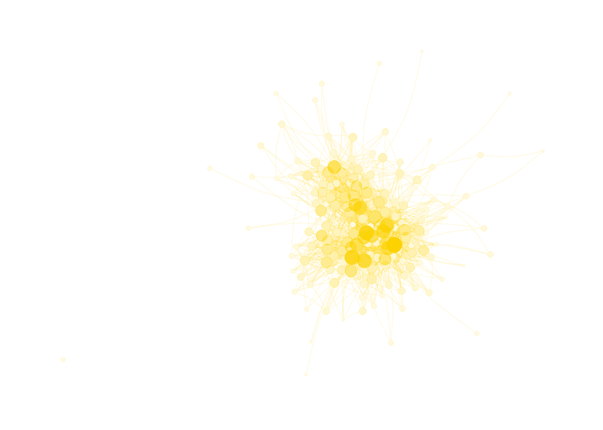

```r
color_network <- "#fcd201"

net_party<- graph_from_data_frame(d = edges_network,
                                    vertices = vertices_network,
                                    directed = T)

g <- as_tbl_graph(net_party) %>%
    tidygraph::activate(nodes) %>%
    dplyr::mutate(label=screen_name,
                  color = color_network,
                  fill = color
                  )
V(g)$degree<- degree(g, mode="in")

V(g)$label <- ifelse(V(g)$degree > quantile(V(g)$degree , 0.9), paste0(V(g)$label), "")
layout <- create_layout(g, layout = 'igraph', algorithm = 'nicely')
got_palette <- c(color_network)

set.seed(42)
x <- g %>%
  ggraph(layout = "fr") +
  geom_edge_arc(colour= color_network,
                lineend = "round",
                strength = .1,
                alpha = .1) +
  geom_node_point(aes(size = degree),
                  col = "white",
                  show.legend = F)+
  geom_node_point(aes(size = degree,
                      alpha = degree,
                      color = color_network),
                  show.legend = F) +
  scale_color_manual(values = got_palette) +
  theme_graph(background = "white")

plot(x, caption = "Network de Cambiemos in 2021 election")
```

```r
library(igraph)
aut <- authority.score(net_party)$vector
wc <- walktrap.community(net_party)
s <- sizes(wc)
centrality_party <- data.frame(party = "Cambiemos",
                         year = "2021",
                         diameter = diameter(net_party, directed = TRUE),
                         mean_distance = mean_distance(net_party),
                         density = edge_density(net_party),
                         screen_eigenvector = paste0("@", na.omit(politicxs_data[politicxs_data$user_id == names(V(net_party))[ which.max(eigen_centrality(net_party)$vector )] , "screen_name"])[1]),
                         screen_autority =  paste0("@",na.omit(politicxs_data[politicxs_data$user_id == names(aut)[which.max(aut)] , "screen_name"])[1]),
                         size_network = gsize(net_party),
                         amount_communities = length(s[s > 2])+1,
                         assortative = round(assortativity_degree(net_party),3),
                         assortative_gender =round(igraph::assortativity_nominal(net_party, as.numeric(as.factor(V(net_party)$gender))),3),
                         assortative_category=round(igraph::assortativity_nominal(net_party, as.numeric(as.factor(V(net_party)$category))),3),
                         farther_nodes = paste0(farthest_vertices(net_party)$vertices[[1]]$screen_name," - ",
                                                farthest_vertices(net_party)$vertices[[2]]$screen_name),
                         path = "Cambiemos_2021.png")
```

```r
network_info<- read_csv("C:/Users/User/Documents/GitHub/guada-blog/_posts/2023-05-03-politicxs-en-twitter-again-online/plots/centrality_info.csv")


pattern1 <- "^@([[:alnum:]_]+)"
pattern2 <- "- @([[:alnum:]_]+)"

usernames <- apply(network_info["farther_nodes"], 1, function(x) {
  matches1 <- str_extract(x, pattern1)
  matches2 <- str_extract(x, pattern2)

  return(c(matches1, matches2))
})
network_info$first_username <- usernames[1,]

network_info$second_username <- gsub("- ", "" , usernames[2,])

network_info$path <- here::here('', paste0(
    '_posts/2023-05-03-politicxs-en-twitter-again-online/plots/', tolower(network_info$path)
  ))

network_info <- network_info %>%
  filter(party != "Otr@s") %>%
  mutate(
  logo = case_when(

    party == "Cambiemos" ~  here::here('', paste0(
    '_posts/2023-05-03-politicxs-en-twitter-again-online/plots/JXC.png')) ,
    party == "Frente de Todos" ~ here::here('', paste0(
    '_posts/2023-05-03-politicxs-en-twitter-again-online/plots/FDT.png')),
    party == "Libertarios" ~ here::here('', paste0(
    '_posts/2023-05-03-politicxs-en-twitter-again-online/plots/Libertarios.png')),
    party == "Frente de Izquierda" ~ here::here('', paste0(
    '_posts/2023-05-03-politicxs-en-twitter-again-online/plots/fit.png'))),
  mean_distance = round(mean_distance, 2),
  density = round(density, 2),
  assortative = round(assortative, 2),
  assortative_gender = round(assortative_gender, 2),
  assortative_category = round(assortative_category, 2)

)
```

### Applying this to all the parties and in different years!

```r
network_info <- data.frame(lapply(network_info, as.character), stringsAsFactors=FALSE)

net_try <- network_info |>
   mutate(link_eig = gsub("@", "https://twitter.com/",screen_eigenvector ),
          link_eig = sprintf('<a href = "%s">%s</a>', link_eig, screen_eigenvector),
          screen_eigenvector1 = map(link_eig, gt::html),
          link_aut = gsub("@", "https://twitter.com/",screen_autority ),
          link_aut = sprintf('<a href = "%s">%s</a>', link_aut, screen_autority),
          screen_autority1 = map(link_aut, gt::html),
          link_first_node = gsub("@", "https://twitter.com/",first_username ),
          link_first_node = sprintf('<a href = "%s">%s</a> ', link_first_node, first_username),
          farther_nodes1= map(link_first_node, gt::html),
          link_second_node = gsub("@", "https://twitter.com/",second_username ),
          link_second_node = sprintf('<a href = "%s">%s</a> ', link_second_node, second_username),
          farther_nodes2= map(link_second_node, gt::html),
          farther_nodes_ =paste(map(link_first_node, gt::html), " - ", map(link_second_node, gt::html))
     ) #|>
```

```r
xaringanExtra::use_panelset()
```

## Elections 2019 🗳️

Network Information by Party

*Elections 2019*

Network Measures

Degree Correlation

Network image

Mean Distance

Density

Authority<sup>1</sup>

Assortative<sup>2</sup>

Assortative (gender)

Assortative (category)

[figure not shown]

3.27

0.03

[@mauriciomacri](https://twitter.com/mauriciomacri)

-0.22

0.12

0.09

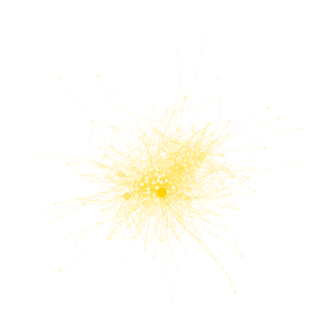

[figure not shown]

3.11

0.02

[@alferdez](https://twitter.com/alferdez)

-0.22

0.09

0.08

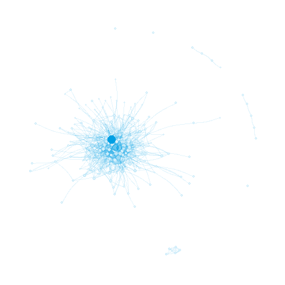

[figure not shown]

1.29

0.25

[@fervilardo](https://twitter.com/fervilardo)

-0.21

-0.37

0.43

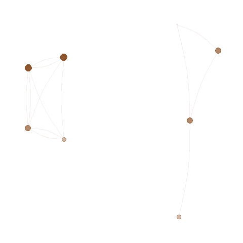

[figure not shown]

1.63

0.1

[@Fte_Izquierda](https://twitter.com/Fte_Izquierda)

0.05

0

0.04

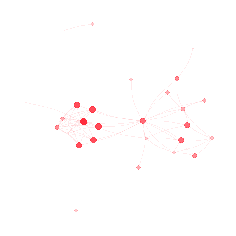

Data: politicxsentwitteR from 01/08/2019 to 31/12/2019

<sup>1</sup> The authority is based on Eigenvector centrality

<sup>2</sup> From 1 to -1. Between closest to 1 more correlation between nodes degree

## Elections 2021 🗳️

Network Information by Party

Network Measures

Degree Correlation

Network image

Mean Distance

Density

Authority<sup>1</sup>

Assortative<sup>2</sup>

Assortative (gender)

Assortative (category)

[figure not shown]

3.14

0.04

[@marioraulnegri](https://twitter.com/marioraulnegri)

-0.14

0.08

0.15

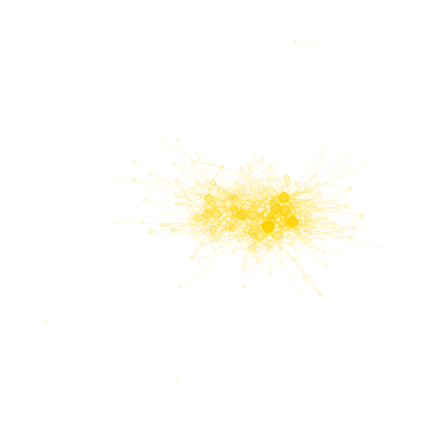

[figure not shown]

2.45

0.05

[@FrenteDeTodos](https://twitter.com/FrenteDeTodos)

-0.22

0.12

0.14

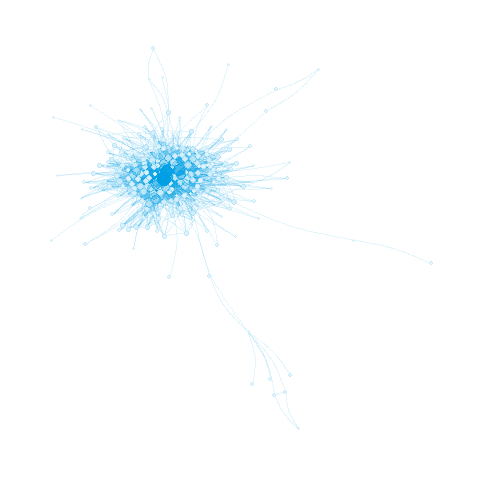

[figure not shown]

1.51

0.17

[@VickyVillarruel](https://twitter.com/VickyVillarruel)

0.08

0.26

0.2

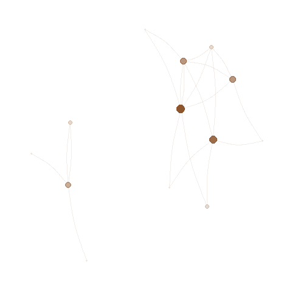

[figure not shown]

1.83

0.27

[@Solanopo](https://twitter.com/Solanopo)

0.01

-0.02

-0.01

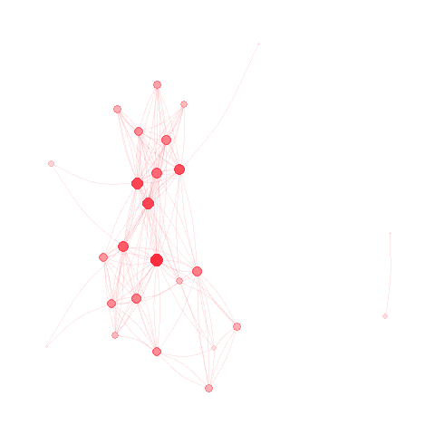

<sup>1</sup> The authority is based on Eigenvector centrality

<sup>2</sup> From 1 to -1. Between closest to 1 more correlation between nodes degree

## Contacts ✉

Guadalupe Gonzalez, [Linkedin](https://www.linkedin.com/in/guadag12/), [Twitter](https://twitter.com/guadag12), [Github](https://github.com/guadag12), [Blogpost](https://www.guadagonzalez.com/).